Brief Report

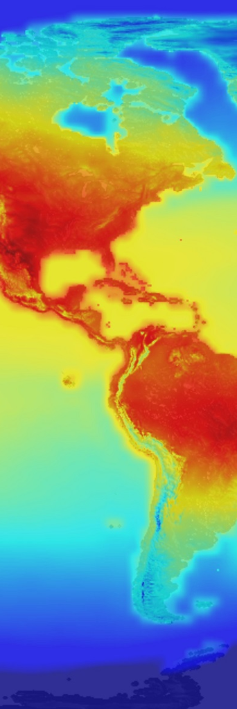

Numeric Literacy and Climate Change Denial Predict Climate Change Worry among Young Adults

## Validating a New Climate Change Worry Scale

## Executive Summary

- Numeric literacy is a measure of how well a person understands and uses numerical information in everyday situations.
- Some evidence suggests that high numeracy may be associated with reduced emotional responding and skepticism in a person’s thoughts about global climate change.
- Participants in this survey study completed a climate change worry scale, climate change denial scale, and numeracy scale. After reading a news story about a troubled ecosystem, participants were asked how much they would donate to an organization working to combat climate change.
- The results showed that both numeracy and climate change denial negatively predicted climate change worry, which in turn positively predicted financial donations.

## Introduction

Numeric literacy, or numeracy, is a person’s ability to understand and use basic numeric information in everyday activities. People with above average numeracy skills are more likely to understand and correctly apply numeric information in the context of problem solving and decision making, whereas low numeracy individuals are less likely to attend to numerical information and more inclined to make decisions guided by emotions and heuristic strategies.<sup>1,2,3,4</sup>

Some researchers have also suggested that low numeracy people are more likely to believe conspiracy theories and distrust scientific experts.<sup>5</sup> However, evidence shows that high numeracy individuals may also be susceptible to these beliefs because they are willing to apply their numeric skills selectively when it comes to emotionally-charged topics (e.g., gun control, climate change), and interpret numerical information in a way that fits their existing views.<sup>6</sup>

### Purpose

**Numeracy**. In the current study, participants were asked complete psychological scales that assessed numeracy, climate change worry, and climate change denial. The primary purpose of this study was to show that both climate change worry and denial were negatively related to numeracy.

**Donations**. After the survey, participants were asked to read a news story about an ecosystem in trouble because of climate change and give an estimate of how much they would be willing to donate to help address the problem. The second purpose of this study was to show that people feel more inclined to help mitigate a consequence of climate change if they experience frequent climate change worry and believe that climate change is actually happening.<sup>4</sup>

**Climate Change Worry**. In past studies, climate change worry has typically been assessed using a single self-report item (How worried are you about climate change?), which be insensitive to all the dimensions of the construct. At least one researcher has developed and validated a psychometric scale for climate change worry,<sup>7</sup> however, many of its 10 items are overly complicated compared to the succinct items that are typical of other measures of worry (see the [Penn State Worry Questionnaire](https://novopsych.com.au/assessments/diagnosis/penn-state-worry-questionnaire-pswq/)). The third purpose of this study was to validate a new brief climate change worry scale, which consisted of 5 concise items.

## Method

### Participants

Participants were 126 U.S. college students between the age of 18 and 23 years old (*M* = 19). All participants received course credit for their participation.

Participants were mostly white (73%) females (67%) who endorsed the Democratic political party (46%) and Christianity (48%).

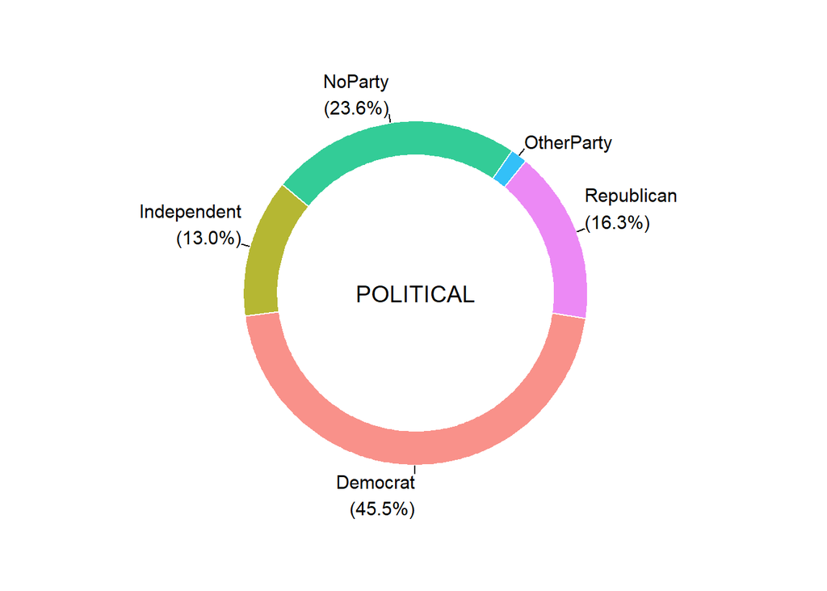

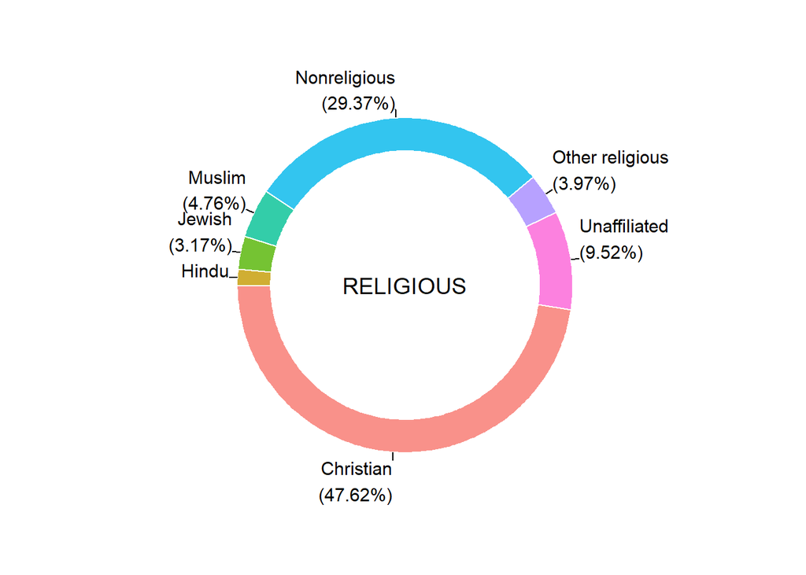

### Materials

**Climate Change Worry Scale** (5-point unipolar scale; Never = 1, Almost Always = 5)

1. I have worrisome thoughts about global climate change.
2. My thoughts about global climate change prevent me from focusing on other things.
3. I worry about how my actions might impact global climate change.
4. Thoughts about global climate change just pop into my mind.
5. I feel stressed out when I hear information about global climate change.

**Climate Change Denial Scale**<sup>8</sup>

1. Which of the following statements reflects your view of when the effects of global warming will begin to happen?
   - They have already begun to happen
   - They will start happening within a few years
   - They will start happening within your lifetime
   - They will not happen within your lifetime, but they will affect future generations
   - They will never happen
2. And from what you have heard or read, do you believe increases in the Earth’s temperature over the last century are due more to:
   - The effects of pollution from human activities
   - Natural changes in the environment that are not due to human activities
3. Just your impression, which one of the following statements do you think is most accurate?
   - Most scientists believe that global warming is occurring
   - Most scientists are unsure about whether global warming is occurring or not
   - Most scientists believe that global warming is not occurring
4. Thinking about what is said in the news, in your view is the seriousness of global warming:
   - Generally underestimated
   - Generally correct
   - Generally exaggerated

**Numeracy Scale**<sup>9</sup>

1. Imagine that we role a fair, six-sided die 1,000 times. Out of 1,000 roles, how many times should the die would come up even (2, 4, or 6)?
2. In the BIG BUCKS LOTTERY, the chances of winning a $10 prize is 1%. How many people should win a $10 prize if 1,000 people each buy a single ticket for the BIG BUCKS LOTTERY?
3. In the ACME PUBLISHING SWEEPSTAKES, the chance of winning a car is 1 in 1,000. What percent of tickets to ACME PUBLISHING SWEEPSTAKES win a car? _____%
4. If the chance of getting a disease is 20 out of 100, this would be the same as having a ____% chance of getting the disease.
5. If the chance of getting a disease is 10%, how many people out of 1000 would be expected to get the disease?

### Procedures

Participants who volunteered for the study were provided with the URL for online study administered in Google Forms. After providing informed consent, participants completed the climate change worry scale, climate change denial scale, and numeracy scale. After completing the survey, participants were asked to read the news story and asked to answer the following question:

> Imagine that you received $25 right now, which you could spend however you liked. How much of this money would you be willing to donate to an organization working to combat climate change?

## Results and Discussion

### Structural Equation Model

A structural equation model (R *lavaan* v0.6-10) that regressed Financial Donation (observed variable) on Climate Worry (latent variable with 5 items), Climate Change Denial (latent variable with 4 items), and Numeracy (latent variable with 5 items) showed a good fit with the data, $\chi^2$(86,126) = 113.3, $p$ = .026, CFI = .959, RMSEA = .050, and all items had loadings greater than 0.4 and $p$ < .002.

The analysis of multiple regression showed that higher Financial Donations were associated with higher Climate Worry, $b^\prime$ = 0.59, SE = 1.1, $p$ < .001, but were not related to Climate Change Denial, $b^\prime$ = -0.02, or Numeracy, $b^\prime$ = 0.12. Higher Climate Worry was associated with lower Climate Change Denial, $b^\prime$ = -0.63, SE = 0.16, $p$ < .001, and lower Numeric Literacy, $b^\prime$ = -0.31, SE = 0.56, $p$ = .012, although these two predictors were not related to each other, $b^\prime$ = -0.15. The path model below shows all standardized regression coefficients.

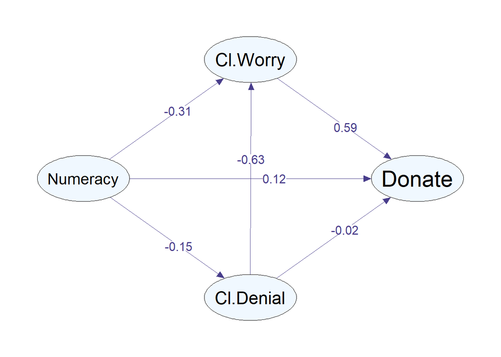

### Path Analysis

The data supported some, but not all hypotheses. Notably, lower numeracy did not predict higher climate change denial, which in turn was not associated with financial donations to an organization working to fight climate change.

Financial donations were, however, indirectly associated with both numeracy and climate change denial through climate change worry. Lower numeracy and lower climate change denial predicted higher climate change worry, which predicted higher financial donations.

### Climate Change Worry Scale

The results suggest that climate change worry exerts a strong influence on people’s willingness to support the fight against climate change, which is consistent with the body of evidence showing that financial giving tends to be guided by emotions. All 5 scale items had a factor loading between 0.766 and 0.861, which suggests that each exerts a strong influence on the latent variable. Although data from a larger national sample will help explore the scale’s performance in the general population, this initial data suggests the scale is a good candidate for assessing the construct with a small number of succinct items.

## References

1. Peters, E. & Dieckmann, N. (2007). Less is more in presenting quality information to consumers. *Medical Care Research and Review, 64(2),* 169-190.
2. Peters, E., Vastfjall, D., Slovic, C. K., Mazzocco, K., & Dickert, S. (2006). Numeracy and decision making. *Psychological Science, 17(5),* 407-413.
3. Schwartz, L. M., Woloshin, S., Black, W. C., & Welch, H.G. (1997). The role of numeracy in understanding the benefit of screening mammography. *Annals of Internal Medicine, 127(11),* 966-72.
4. Hart, P. S. (2013). The role of numeracy in moderating the influence of statistics in climate change messages. *Public Understanding of Science, 22(7),* 785-798.
5. Peters, E. (2020). Numeracy and the Perception and Communication of Risk. *Annals of the New York Academy of Sciences, 1128,* 1-7.
6. Kahan, D. M., Peters, E., Dawson, E. C., & Slovic, P. (2017). Motivated numeracy and enlightened self-government. *Behavioral Public Policy, 1,* 54-86.
7. Stewart, A. E. (2021). Psychometric properties of the climate change worry scale. *International Journal of Environmental Research and Public Health, 18,* 1-22.
8. McCright, A. M & Dunlap, R. E. (2011). Cool dudes: The denial of climate change among conservative white males in the United States. *Global Environmental Change, 21(4),* 1163-1172.
9. Weller, J. A., Dieckmann, N. F., Mertz, C.K., et al. (2013). Development and testing of an abbreviated numeracy scale: A Rasch analysis approach. *Journal of Behavioral Decision Making, 26,* 198-212.

This report was created with RStudio and RMarkdown